# Risk Factor Analysis

## Outcome Variable

**Outcome Variable:** co_occurence

## Predictor Variables

**Intervention Variable:** ever_sunderweight06

**Adjustment Set:**

unadjusted

## Stratifying Variables

The analysis was stratified on these variable(s):

- studyid
- country

## Data Summary

| studyid | country | ever_sunderweight06 | co_occurence | n_cell | n |
| --- | --- | --- | --- | --- | --- |
| ki0047075b-MAL-ED | BANGLADESH | 0 | 0 | 200 | 221 |
| ki0047075b-MAL-ED | BANGLADESH | 0 | 1 | 11 | 221 |
| ki0047075b-MAL-ED | BANGLADESH | 1 | 0 | 7 | 221 |
| ki0047075b-MAL-ED | BANGLADESH | 1 | 1 | 3 | 221 |
| ki0047075b-MAL-ED | BRAZIL | 0 | 0 | 179 | 180 |
| ki0047075b-MAL-ED | BRAZIL | 0 | 1 | 1 | 180 |
| ki0047075b-MAL-ED | BRAZIL | 1 | 0 | 0 | 180 |
| ki0047075b-MAL-ED | BRAZIL | 1 | 1 | 0 | 180 |
| ki0047075b-MAL-ED | INDIA | 0 | 0 | 189 | 228 |
| ki0047075b-MAL-ED | INDIA | 0 | 1 | 10 | 228 |
| ki0047075b-MAL-ED | INDIA | 1 | 0 | 22 | 228 |
| ki0047075b-MAL-ED | INDIA | 1 | 1 | 7 | 228 |
| ki0047075b-MAL-ED | NEPAL | 0 | 0 | 217 | 229 |
| ki0047075b-MAL-ED | NEPAL | 0 | 1 | 3 | 229 |
| ki0047075b-MAL-ED | NEPAL | 1 | 0 | 8 | 229 |
| ki0047075b-MAL-ED | NEPAL | 1 | 1 | 1 | 229 |
| ki0047075b-MAL-ED | PERU | 0 | 0 | 212 | 222 |
| ki0047075b-MAL-ED | PERU | 0 | 1 | 4 | 222 |
| ki0047075b-MAL-ED | PERU | 1 | 0 | 4 | 222 |
| ki0047075b-MAL-ED | PERU | 1 | 1 | 2 | 222 |
| ki0047075b-MAL-ED | SOUTH AFRICA | 0 | 0 | 231 | 241 |
| ki0047075b-MAL-ED | SOUTH AFRICA | 0 | 1 | 4 | 241 |
| ki0047075b-MAL-ED | SOUTH AFRICA | 1 | 0 | 6 | 241 |
| ki0047075b-MAL-ED | SOUTH AFRICA | 1 | 1 | 0 | 241 |
| ki0047075b-MAL-ED | TANZANIA, UNITED REPUBLIC OF | 0 | 0 | 218 | 225 |
| ki0047075b-MAL-ED | TANZANIA, UNITED REPUBLIC OF | 0 | 1 | 0 | 225 |
| ki0047075b-MAL-ED | TANZANIA, UNITED REPUBLIC OF | 1 | 0 | 6 | 225 |
| ki0047075b-MAL-ED | TANZANIA, UNITED REPUBLIC OF | 1 | 1 | 1 | 225 |
| ki1000108-CMC-V-BCS-2002 | INDIA | 0 | 0 | 290 | 364 |
| ki1000108-CMC-V-BCS-2002 | INDIA | 0 | 1 | 11 | 364 |

[output cut: 90 more lines]

The following strata were considered:

- studyid: ki0047075b-MAL-ED, country: BANGLADESH
- studyid: ki0047075b-MAL-ED, country: BRAZIL
- studyid: ki0047075b-MAL-ED, country: INDIA
- studyid: ki0047075b-MAL-ED, country: NEPAL
- studyid: ki0047075b-MAL-ED, country: PERU
- studyid: ki0047075b-MAL-ED, country: SOUTH AFRICA
- studyid: ki0047075b-MAL-ED, country: TANZANIA, UNITED REPUBLIC OF
- studyid: ki1000108-CMC-V-BCS-2002, country: INDIA
- studyid: ki1000108-IRC, country: INDIA
- studyid: ki1000109-EE, country: PAKISTAN
- studyid: ki1000109-ResPak, country: PAKISTAN
- studyid: ki1000304b-SAS-CompFeed, country: INDIA
- studyid: ki1000304b-SAS-FoodSuppl, country: INDIA
- studyid: ki1017093-NIH-Birth, country: BANGLADESH
- studyid: ki1017093b-PROVIDE, country: BANGLADESH
- studyid: ki1017093c-NIH-Crypto, country: BANGLADESH
- studyid: ki1066203-TanzaniaChild2, country: TANZANIA, UNITED REPUBLIC OF
- studyid: ki1101329-Keneba, country: GAMBIA
- studyid: ki1113344-GMS-Nepal, country: NEPAL
- studyid: ki1114097-CMIN, country: BANGLADESH
- studyid: ki1114097-CMIN, country: BRAZIL
- studyid: ki1114097-CMIN, country: GUINEA-BISSAU
- studyid: ki1114097-CMIN, country: PERU
- studyid: ki1114097-CONTENT, country: PERU
- studyid: ki1119695-PROBIT, country: BELARUS
- studyid: ki1126311-ZVITAMBO, country: ZIMBABWE
- studyid: ki1135781-COHORTS, country: GUATEMALA
- studyid: ki1135781-COHORTS, country: PHILIPPINES
- studyid: ki1148112-LCNI-5, country: MALAWI
- studyid: kiGH5241-JiVitA-4, country: BANGLADESH

### Dropped Strata

Some strata were dropped due to rare outcomes:

- studyid: ki0047075b-MAL-ED, country: BANGLADESH
- studyid: ki0047075b-MAL-ED, country: BRAZIL
- studyid: ki0047075b-MAL-ED, country: NEPAL
- studyid: ki0047075b-MAL-ED, country: PERU
- studyid: ki0047075b-MAL-ED, country: SOUTH AFRICA
- studyid: ki0047075b-MAL-ED, country: TANZANIA, UNITED REPUBLIC OF
- studyid: ki1000109-ResPak, country: PAKISTAN
- studyid: ki1066203-TanzaniaChild2, country: TANZANIA, UNITED REPUBLIC OF
- studyid: ki1114097-CMIN, country: BRAZIL
- studyid: ki1114097-CMIN, country: GUINEA-BISSAU
- studyid: ki1114097-CMIN, country: PERU
- studyid: ki1114097-CONTENT, country: PERU
- studyid: ki1119695-PROBIT, country: BELARUS
- studyid: ki1148112-LCNI-5, country: MALAWI

## Methods Detail

We’re interested in the causal parameters $E[Y_a]$ for all values of $a \in \mathcal{A}$. These parameters represent the mean outcome if, possibly contrary to fact, we intervened to set all units to have $A=a$. Under the randomization and positivity assumptions, these are identified by the statistical parameters $\psi_a=E_W[E_{Y|A,W}(Y|A=a,W)]$. In addition, we’re interested in the mean of $Y$, $E[Y]$ under no intervention (the observed mean). We will estimate these parameters by using SuperLearner to fit the relevant likelihood factors – $E_{Y|A,W}(Y|A=a,W)$ and $p(A=a|W)$, and then updating our likelihood fit using a joint TMLE.

For unadjusted analyses ($W=\{\}$), initial likelihoods were estimated using Lrnr_glm to estimate the simple $E(Y|A)$ and Lrnr_mean to estimate $p(A)$. For adjusted analyses, a small library containing Lrnr_glmnet, Lrnr_xgboost, and Lrnr_mean was used.

Having estimated these parameters, we will then use the delta method to estimate relative risks and attributable risks relative to a prespecified baseline level of $A$.

# Results Detail

## Results Plots

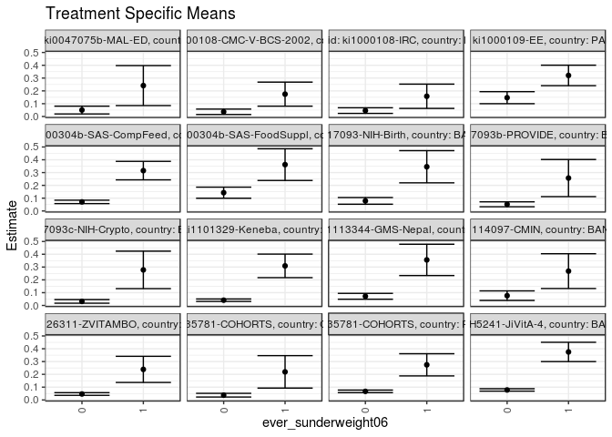

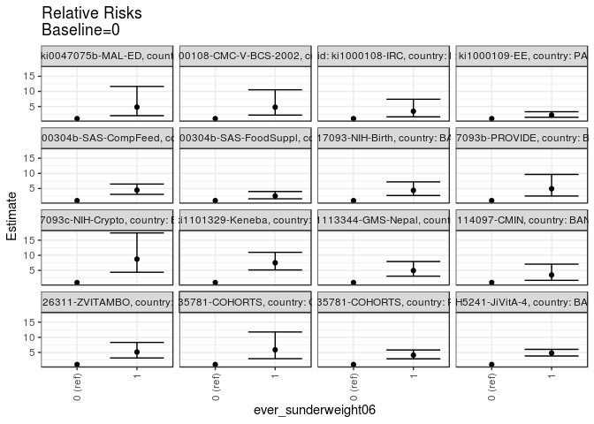

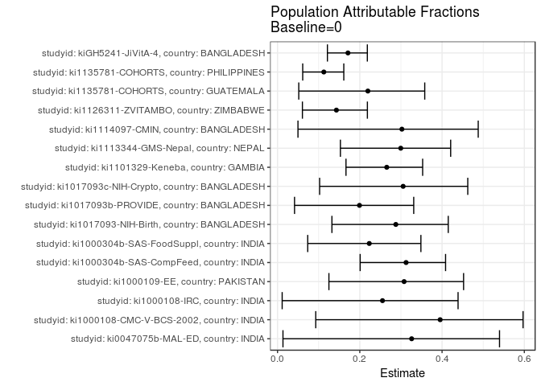

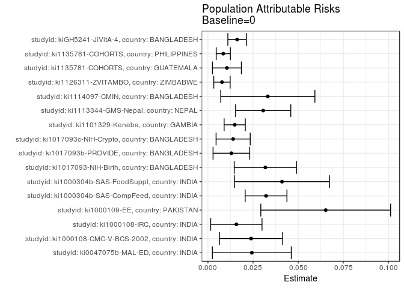

## Results Table

### Parameter: TSM

| studyid | country | intervention_level | baseline_level | estimate | ci_lower | ci_upper |
| --- | --- | --- | --- | --- | --- | --- |
| ki0047075b-MAL-ED | INDIA | 0 | NA | 0.0502513 | 0.0198316 | 0.0806709 |
| ki0047075b-MAL-ED | INDIA | 1 | NA | 0.2413793 | 0.0852926 | 0.3974660 |
| ki1000108-CMC-V-BCS-2002 | INDIA | 0 | NA | 0.0365449 | 0.0153177 | 0.0577720 |
| ki1000108-CMC-V-BCS-2002 | INDIA | 1 | NA | 0.1746032 | 0.0807319 | 0.2684744 |
| ki1000108-IRC | INDIA | 0 | NA | 0.0459770 | 0.0239455 | 0.0680086 |
| ki1000108-IRC | INDIA | 1 | NA | 0.1578947 | 0.0631152 | 0.2526743 |
| ki1000109-EE | PAKISTAN | 0 | NA | 0.1467890 | 0.0997435 | 0.1938345 |
| ki1000109-EE | PAKISTAN | 1 | NA | 0.3206107 | 0.2405750 | 0.4006464 |
| ki1000304b-SAS-CompFeed | INDIA | 0 | NA | 0.0708372 | 0.0576975 | 0.0839768 |
| ki1000304b-SAS-CompFeed | INDIA | 1 | NA | 0.3151515 | 0.2428749 | 0.3874281 |
| ki1000304b-SAS-FoodSuppl | INDIA | 0 | NA | 0.1428571 | 0.0995831 | 0.1861311 |
| ki1000304b-SAS-FoodSuppl | INDIA | 1 | NA | 0.3620690 | 0.2381841 | 0.4859538 |
| ki1017093-NIH-Birth | BANGLADESH | 0 | NA | 0.0788177 | 0.0525791 | 0.1050564 |
| ki1017093-NIH-Birth | BANGLADESH | 1 | NA | 0.3454545 | 0.2196479 | 0.4712612 |
| ki1017093b-PROVIDE | BANGLADESH | 0 | NA | 0.0522244 | 0.0330295 | 0.0714193 |
| ki1017093b-PROVIDE | BANGLADESH | 1 | NA | 0.2571429 | 0.1122164 | 0.4020693 |
| ki1017093c-NIH-Crypto | BANGLADESH | 0 | NA | 0.0317726 | 0.0177038 | 0.0458413 |
| ki1017093c-NIH-Crypto | BANGLADESH | 1 | NA | 0.2777778 | 0.1313499 | 0.4242057 |
| ki1101329-Keneba | GAMBIA | 0 | NA | 0.0410380 | 0.0314836 | 0.0505924 |
| ki1101329-Keneba | GAMBIA | 1 | NA | 0.3092784 | 0.2172732 | 0.4012835 |
| ki1113344-GMS-Nepal | NEPAL | 0 | NA | 0.0715746 | 0.0487058 | 0.0944434 |
| ki1113344-GMS-Nepal | NEPAL | 1 | NA | 0.3559322 | 0.2336486 | 0.4782158 |
| ki1114097-CMIN | BANGLADESH | 0 | NA | 0.0765306 | 0.0392342 | 0.1138270 |
| ki1114097-CMIN | BANGLADESH | 1 | NA | 0.2682927 | 0.1323839 | 0.4042014 |
| ki1126311-ZVITAMBO | ZIMBABWE | 0 | NA | 0.0465702 | 0.0362065 | 0.0569339 |
| ki1126311-ZVITAMBO | ZIMBABWE | 1 | NA | 0.2388060 | 0.1366857 | 0.3409263 |
| ki1135781-COHORTS | GUATEMALA | 0 | NA | 0.0373692 | 0.0229869 | 0.0517515 |
| ki1135781-COHORTS | GUATEMALA | 1 | NA | 0.2195122 | 0.0927252 | 0.3462992 |
| ki1135781-COHORTS | PHILIPPINES | 0 | NA | 0.0670297 | 0.0569957 | 0.0770638 |
| ki1135781-COHORTS | PHILIPPINES | 1 | NA | 0.2745098 | 0.1878875 | 0.3611322 |
| kiGH5241-JiVitA-4 | BANGLADESH | 0 | NA | 0.0781962 | 0.0688486 | 0.0875438 |
| kiGH5241-JiVitA-4 | BANGLADESH | 1 | NA | 0.3750000 | 0.2995867 | 0.4504133 |

### Parameter: E(Y)

| studyid | country | intervention_level | baseline_level | estimate | ci_lower | ci_upper |
| --- | --- | --- | --- | --- | --- | --- |
| ki0047075b-MAL-ED | INDIA | NA | NA | 0.0745614 | 0.0403897 | 0.1087331 |
| ki1000108-CMC-V-BCS-2002 | INDIA | NA | NA | 0.0604396 | 0.0359254 | 0.0849538 |
| ki1000108-IRC | INDIA | NA | NA | 0.0617284 | 0.0382610 | 0.0851958 |
| ki1000109-EE | PAKISTAN | NA | NA | 0.2120344 | 0.1690891 | 0.2549796 |
| ki1000304b-SAS-CompFeed | INDIA | NA | NA | 0.1030351 | 0.0907482 | 0.1153221 |
| ki1000304b-SAS-FoodSuppl | INDIA | NA | NA | 0.1838710 | 0.1406788 | 0.2270631 |
| ki1017093-NIH-Birth | BANGLADESH | NA | NA | 0.1106291 | 0.0819645 | 0.1392936 |
| ki1017093b-PROVIDE | BANGLADESH | NA | NA | 0.0652174 | 0.0446012 | 0.0858336 |
| ki1017093c-NIH-Crypto | BANGLADESH | NA | NA | 0.0457413 | 0.0294659 | 0.0620168 |
| ki1101329-Keneba | GAMBIA | NA | NA | 0.0558723 | 0.0451208 | 0.0666238 |
| ki1113344-GMS-Nepal | NEPAL | NA | NA | 0.1021898 | 0.0768063 | 0.1275732 |
| ki1114097-CMIN | BANGLADESH | NA | NA | 0.1097046 | 0.0698323 | 0.1495770 |
| ki1126311-ZVITAMBO | ZIMBABWE | NA | NA | 0.0543478 | 0.0434257 | 0.0652699 |
| ki1135781-COHORTS | GUATEMALA | NA | NA | 0.0478873 | 0.0321700 | 0.0636047 |
| ki1135781-COHORTS | PHILIPPINES | NA | NA | 0.0755323 | 0.0651490 | 0.0859156 |
| kiGH5241-JiVitA-4 | BANGLADESH | NA | NA | 0.0943525 | 0.0838117 | 0.1048932 |

### Parameter: RR

| studyid | country | intervention_level | baseline_level | estimate | ci_lower | ci_upper |
| --- | --- | --- | --- | --- | --- | --- |
| ki0047075b-MAL-ED | INDIA | 0 | 0 | 1.000000 | 1.000000 | 1.000000 |
| ki0047075b-MAL-ED | INDIA | 1 | 0 | 4.803448 | 1.980913 | 11.647715 |
| ki1000108-CMC-V-BCS-2002 | INDIA | 0 | 0 | 1.000000 | 1.000000 | 1.000000 |
| ki1000108-CMC-V-BCS-2002 | INDIA | 1 | 0 | 4.777778 | 2.165177 | 10.542861 |
| ki1000108-IRC | INDIA | 0 | 0 | 1.000000 | 1.000000 | 1.000000 |
| ki1000108-IRC | INDIA | 1 | 0 | 3.434210 | 1.593143 | 7.402850 |
| ki1000109-EE | PAKISTAN | 0 | 0 | 1.000000 | 1.000000 | 1.000000 |
| ki1000109-EE | PAKISTAN | 1 | 0 | 2.184160 | 1.454969 | 3.278802 |
| ki1000304b-SAS-CompFeed | INDIA | 0 | 0 | 1.000000 | 1.000000 | 1.000000 |
| ki1000304b-SAS-CompFeed | INDIA | 1 | 0 | 4.448957 | 3.061532 | 6.465136 |
| ki1000304b-SAS-FoodSuppl | INDIA | 0 | 0 | 1.000000 | 1.000000 | 1.000000 |
| ki1000304b-SAS-FoodSuppl | INDIA | 1 | 0 | 2.534483 | 1.604815 | 4.002705 |
| ki1017093-NIH-Birth | BANGLADESH | 0 | 0 | 1.000000 | 1.000000 | 1.000000 |
| ki1017093-NIH-Birth | BANGLADESH | 1 | 0 | 4.382955 | 2.675984 | 7.178776 |
| ki1017093b-PROVIDE | BANGLADESH | 0 | 0 | 1.000000 | 1.000000 | 1.000000 |
| ki1017093b-PROVIDE | BANGLADESH | 1 | 0 | 4.923809 | 2.512363 | 9.649840 |
| ki1017093c-NIH-Crypto | BANGLADESH | 0 | 0 | 1.000000 | 1.000000 | 1.000000 |
| ki1017093c-NIH-Crypto | BANGLADESH | 1 | 0 | 8.742690 | 4.391987 | 17.403201 |
| ki1101329-Keneba | GAMBIA | 0 | 0 | 1.000000 | 1.000000 | 1.000000 |
| ki1101329-Keneba | GAMBIA | 1 | 0 | 7.536386 | 5.165412 | 10.995660 |
| ki1113344-GMS-Nepal | NEPAL | 0 | 0 | 1.000000 | 1.000000 | 1.000000 |
| ki1113344-GMS-Nepal | NEPAL | 1 | 0 | 4.972881 | 3.110648 | 7.949968 |
| ki1114097-CMIN | BANGLADESH | 0 | 0 | 1.000000 | 1.000000 | 1.000000 |
| ki1114097-CMIN | BANGLADESH | 1 | 0 | 3.505691 | 1.735779 | 7.080318 |
| ki1126311-ZVITAMBO | ZIMBABWE | 0 | 0 | 1.000000 | 1.000000 | 1.000000 |
| ki1126311-ZVITAMBO | ZIMBABWE | 1 | 0 | 5.127874 | 3.166485 | 8.304188 |
| ki1135781-COHORTS | GUATEMALA | 0 | 0 | 1.000000 | 1.000000 | 1.000000 |
| ki1135781-COHORTS | GUATEMALA | 1 | 0 | 5.874146 | 2.934372 | 11.759107 |
| ki1135781-COHORTS | PHILIPPINES | 0 | 0 | 1.000000 | 1.000000 | 1.000000 |
| ki1135781-COHORTS | PHILIPPINES | 1 | 0 | 4.095343 | 2.888076 | 5.807268 |
| kiGH5241-JiVitA-4 | BANGLADESH | 0 | 0 | 1.000000 | 1.000000 | 1.000000 |
| kiGH5241-JiVitA-4 | BANGLADESH | 1 | 0 | 4.795629 | 3.820083 | 6.020302 |

### Parameter: PAR

| studyid | country | intervention_level | baseline_level | estimate | ci_lower | ci_upper |
| --- | --- | --- | --- | --- | --- | --- |
| ki0047075b-MAL-ED | INDIA | 0 | NA | 0.0243101 | 0.0024528 | 0.0461675 |
| ki1000108-CMC-V-BCS-2002 | INDIA | 0 | NA | 0.0238947 | 0.0063924 | 0.0413970 |
| ki1000108-IRC | INDIA | 0 | NA | 0.0157514 | 0.0015403 | 0.0299625 |
| ki1000109-EE | PAKISTAN | 0 | NA | 0.0652454 | 0.0292932 | 0.1011976 |
| ki1000304b-SAS-CompFeed | INDIA | 0 | NA | 0.0321980 | 0.0206243 | 0.0437717 |
| ki1000304b-SAS-FoodSuppl | INDIA | 0 | NA | 0.0410138 | 0.0146765 | 0.0673511 |
| ki1017093-NIH-Birth | BANGLADESH | 0 | NA | 0.0318113 | 0.0145641 | 0.0490586 |
| ki1017093b-PROVIDE | BANGLADESH | 0 | NA | 0.0129930 | 0.0028290 | 0.0231571 |
| ki1017093c-NIH-Crypto | BANGLADESH | 0 | NA | 0.0139687 | 0.0045115 | 0.0234260 |
| ki1101329-Keneba | GAMBIA | 0 | NA | 0.0148343 | 0.0089687 | 0.0206999 |
| ki1113344-GMS-Nepal | NEPAL | 0 | NA | 0.0306151 | 0.0153197 | 0.0459106 |
| ki1114097-CMIN | BANGLADESH | 0 | NA | 0.0331740 | 0.0070960 | 0.0592520 |
| ki1126311-ZVITAMBO | ZIMBABWE | 0 | NA | 0.0077777 | 0.0032415 | 0.0123138 |
| ki1135781-COHORTS | GUATEMALA | 0 | NA | 0.0105181 | 0.0025134 | 0.0185228 |
| ki1135781-COHORTS | PHILIPPINES | 0 | NA | 0.0085026 | 0.0045806 | 0.0124246 |
| kiGH5241-JiVitA-4 | BANGLADESH | 0 | NA | 0.0161563 | 0.0110324 | 0.0212801 |

### Parameter: PAF

| studyid | country | intervention_level | baseline_level | estimate | ci_lower | ci_upper |
| --- | --- | --- | --- | --- | --- | --- |
| ki0047075b-MAL-ED | INDIA | 0 | NA | 0.3260420 | 0.0132207 | 0.5396950 |
| ki1000108-CMC-V-BCS-2002 | INDIA | 0 | NA | 0.3953488 | 0.0929021 | 0.5969530 |
| ki1000108-IRC | INDIA | 0 | NA | 0.2551724 | 0.0112776 | 0.4389040 |
| ki1000109-EE | PAKISTAN | 0 | NA | 0.3077114 | 0.1249187 | 0.4523211 |
| ki1000304b-SAS-CompFeed | INDIA | 0 | NA | 0.3124951 | 0.2008589 | 0.4085362 |
| ki1000304b-SAS-FoodSuppl | INDIA | 0 | NA | 0.2230576 | 0.0733943 | 0.3485477 |
| ki1017093-NIH-Birth | BANGLADESH | 0 | NA | 0.2875495 | 0.1322478 | 0.4150568 |
| ki1017093b-PROVIDE | BANGLADESH | 0 | NA | 0.1992263 | 0.0413432 | 0.3311073 |
| ki1017093c-NIH-Crypto | BANGLADESH | 0 | NA | 0.3053858 | 0.1023445 | 0.4625010 |
| ki1101329-Keneba | GAMBIA | 0 | NA | 0.2655032 | 0.1664264 | 0.3528039 |
| ki1113344-GMS-Nepal | NEPAL | 0 | NA | 0.2995910 | 0.1528559 | 0.4209099 |
| ki1114097-CMIN | BANGLADESH | 0 | NA | 0.3023940 | 0.0496978 | 0.4878954 |
| ki1126311-ZVITAMBO | ZIMBABWE | 0 | NA | 0.1431089 | 0.0604934 | 0.2184595 |
| ki1135781-COHORTS | GUATEMALA | 0 | NA | 0.2196430 | 0.0516370 | 0.3578861 |
| ki1135781-COHORTS | PHILIPPINES | 0 | NA | 0.1125690 | 0.0612236 | 0.1611061 |
| kiGH5241-JiVitA-4 | BANGLADESH | 0 | NA | 0.1712330 | 0.1212704 | 0.2183548 |